# Piano_plot_notes_July_2023

Michael Roswell

2023-07-20

# Basics: Defining frequentist p-values

We define a p-value to be the probability of a particular observation (or one that is more extreme), given that a particular statistical hypothesis is true.

Formally, we define the one-tailed p-value for an observation $x$ and the statistical hypothesis $\Theta$ as $p_{\Theta}(x|\Theta)$; the probability of observing a parameter as or more extreme than $x$, and define 1-tailed p-values as
$$p^{-}_{\Theta}=P(X\leq x|\Theta)$$
and
$$p^{+}_{\Theta}=P(X\geq x|\Theta)$$

where $X$ is a random variable, and $\Theta$ describes the statistical hypothesis.

p-values describe an observation $x$ in terms of the quantiles of a random variable. If $\Theta$ is true, and $X$ is a continuous random variable, then the probability density function of $p_{\Theta}(X)$ is uniform on $[0,1]$, by the probability integral transform (Casella and Berger 2002).

# Twitter post prompts

Richard McElreath posted on [twitter](https://twitter.com/rlmcelreath/status/1677322772719054849) how striking [this simulation](https://gist.githubusercontent.com/rmcelreath/4f7010e8d5688c69bbeb7008f0aabe65/raw/3bfde2a7d162038bf54856b649b4c268573fc061/p_under_null.r) was. His point was that even a continuous test statistic (like the Wald, which we think the GLM is using), when driven by a GLM with data that are sampled from a discrete enough distribution, won’t generate continuous, uniform p-values under the null hypothesis. We think there might be ways to reformulate the p-value/ sampling distribution for reasonable test statistics( e.g., a Wald or Likelihood Ratio) so that we can get p-values that look more like true probabilities when data are generated under a null model/null hypothesis.

# Our take:

People should think about this stuff more. To help them, we created checkPlots, and an R package to make them. The R package makes the plots, but leaves the p-value/ CI simulations to the user.

[output not shown]

Everyone agrees that with continuous statistics driven by continuous random variables, the uniform p-values should and do happen. Here’s a simple example with a 1-sample t-test:

```r
#  generate data
set.seed(7082)
numSims <- 3e4
n <- 100



sd<-4

## normal simulation
datNorm<-map_dfr(c(11,15,22,36), function(mymean){
  map_dfr(1:numSims, function(x){
    data.frame(mu=mymean, t(rnorm(n, mean=mymean, sd)))
  })
})

# get p-values and CI from the t distribution

normtests<- map_dfr(1:length(datNorm$mu), function(samp){
  p<-t.test(datNorm[samp, -1], mu=datNorm[samp,1], alternative="l")$p.value
  ci<-t.test(datNorm[samp, -1], mu=datNorm[samp,1])
  lower<-ci$conf.int[1]
  upper<-ci$conf.int[2]
  est<-ci$estimate
  return(data.frame(p, lower, upper, est, tm=datNorm[samp,1]))
})
```

We can look at the p-values from testing the null hypothesis with a “Checkplot”

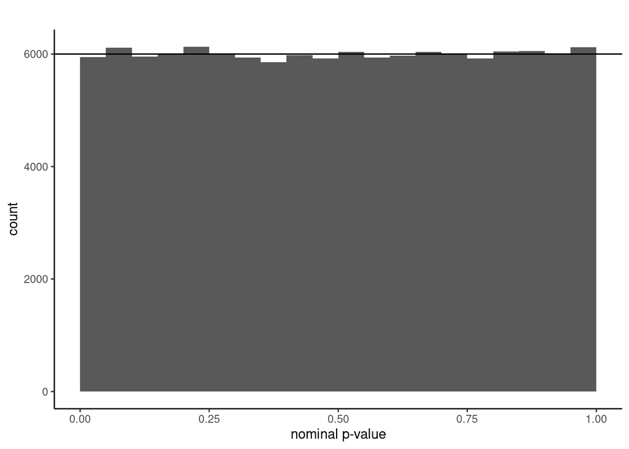

```r
checkPlot(normtests)+
  theme_classic()
```

Things get funnier with discrete test statistics, but they are solveable. We can generate binomial samples and p-values based on a number of tests, such as the Clopper-Pearson exact test, the chi-squared test, or the Wald test.

```r
# binomial simulation
to_checkplot <- map_dfr(c(0.5, 0.75, 0.85, 0.9, 0.97), function(prob){
  dat <- rbinom(numSims, n, prob)
  k<-map_dfr(c("binom.test", "chisq", "wald"), function(testv){
    data.frame(multBinom(
      dat = dat, prob = prob, n = n, testv = testv)
      , testv
      , prob)

  })
  return(k)
})

to_checkplot <- to_checkplot %>%
  mutate(testv=factor(c("Clopper-Pearson exact", "chi squared", "Wald")[as.numeric(as.factor(testv))]
                      , levels=c("Clopper-Pearson exact", "chi squared", "Wald")))
```

And we can look at the p-values. Here, for the Clopper-Pearson exact test we use 1-tailed p-values, which are [intentionally] conservative.

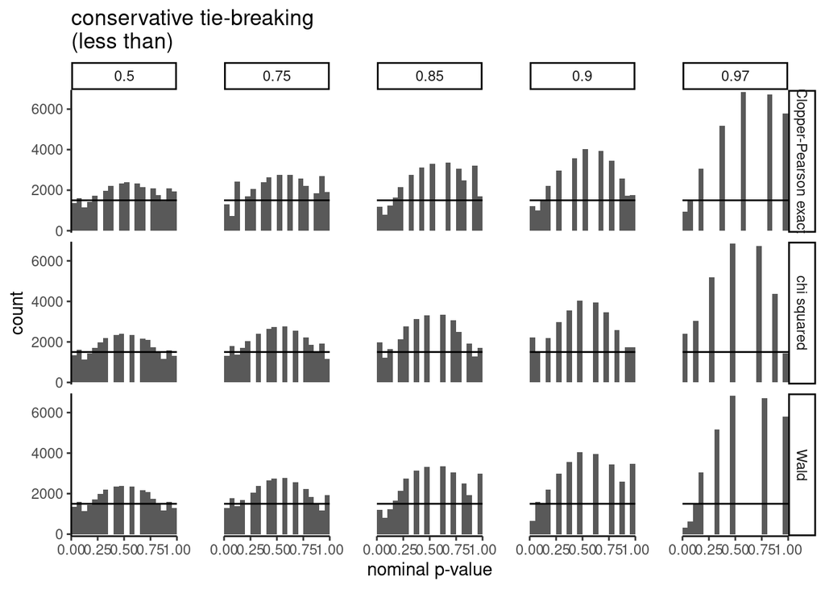

```r
to_checkplot_lower <- to_checkplot %>% mutate(p = cp)

checkPlot(to_checkplot_lower
          , facets = 15)+
  facet_grid(testv~prob, scales="free_y")+
  labs(x="nominal p-value", title = "conservative tie-breaking \n(less than)")+
  scale_x_continuous(expand=c(0,0)) +
  scale_y_continuous(expand=c(0,100))+
  theme_classic() +
  theme(panel.spacing.x = unit(2, "lines"))
```

While these have the undesirable jaggedness in the distribution of p-values under the null, we can solve this for this simple, 1-sample case for the exact test. To do this we “fuzz” the p-values (and need to check out Geyer and Meedon 2005 https://doi.org/10.1214/088342305000000340 to know what “fuzzing” means in general)

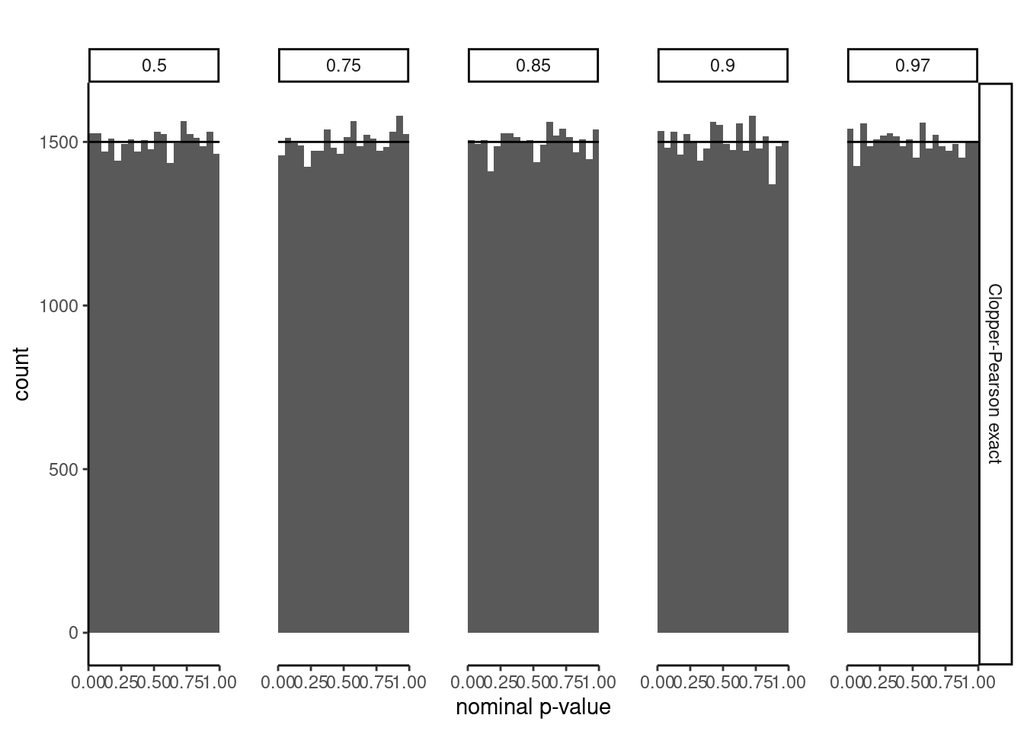

```r
checkPlot(to_checkplot %>%
            filter(testv == "Clopper-Pearson exact")
          , facets = 5)+
  facet_grid(testv~prob, scales="free_y")+
  labs(x="nominal p-value", main = "uniform tie-breaking")+
  scale_x_continuous(expand=c(0,0)) +
  scale_y_continuous(expand=c(0,100))+
  theme_classic() +
  theme(panel.spacing.x = unit(2, "lines"))
```

But it’s not as obvious how we might do something similar in the more complex case where we’re interested in p-values for GLM parameters, as in a typical Wald test or Likelihood Ratio Test (and this is what McElreath was writing about in the first place).

We left this wondering if there were permutation-based tools to get better Wald or LR test statistics (like 1-sided p-values in exact tests) for something complicated but useful like a GLM, where the sampling distribution of the parameter of interest might be hard to know (it’s not chi-squared or z, nor is it binomial or multinomial exactly).